# A3 - Modelizacion predictiva

Javier Gómez de Diego

# **1. Regresión lineal**

El objetivo de esta actividad es demostrar la existencia de relación lineal entre los contaminantes atmosféricos y las variables metereológicas.

Para ello, cargamos los datos del archivo *dat_Air*, que están separados por el carácter “**,**”

```r
d <- read.csv("dat_Air.csv", sep=",")
```

Verificamos los datos.

```r
head(d)
```

|  | Estacion | latitud | longitud | Fecha | Periodo | SO2 | H2S | NO | NO2 | NOX | O3 | PM10 | PM25 | BEN | TOL | MXIL | Dir_Aire | Vel | Tmp | HR | PRB | RS | LL |
| --- | --- | --- | --- | --- | --- | --- | --- | --- | --- | --- | --- | --- | --- | --- | --- | --- | --- | --- | --- | --- | --- | --- | --- |
| 1 | 12 | 43.52096 | -5.690707 | 11/7/2021 | 24 | 1 | 18.3 | 5 | 36 | 43 | 5 | 95 | 30 | 1.6 | 2.3 | 3.2 | 260 | 1.49 | 11.8 | 93 | 1025 | 36 | 0 |
| 2 | 12 | 43.52096 | -5.690707 | 11/7/2021 | 23 | 1 | 6.2 | 2 | 22 | 24 | 10 | 80 | 23 | 0.7 | 1.8 | 2.7 | 201 | 0.98 | 11.6 | 93 | 1025 | 36 | 0 |
| 3 | 12 | 43.52096 | -5.690707 | 11/7/2021 | 22 | 1 | 4.3 | 1 | 19 | 20 | 14 | 38 | 15 | 0.6 | 1.1 | 3.1 | 296 | 0.98 | 11.2 | 92 | 1025 | 37 | 0 |
| 4 | 12 | 43.52096 | -5.690707 | 11/7/2021 | 21 | 1 | 2.7 | 4 | 21 | 26 | 11 | 36 | 12 | 0.9 | 1.3 | 2.2 | 185 | 0.99 | 11.9 | 88 | 1026 | 37 | 0 |
| 5 | 12 | 43.52096 | -5.690707 | 11/7/2021 | 20 | 1 | 2.1 | 2 | 18 | 20 | 16 | 30 | 12 | 0.2 | 0.6 | 0.8 | 297 | 0.99 | 12.4 | 85 | 1026 | 37 | 0 |
| 6 | 12 | 43.52096 | -5.690707 | 11/7/2021 | 19 | 1 | 1.3 | 1 | 10 | 10 | 24 | 21 | 17 | 0.3 | 0.6 | 1.0 | 295 | 0.99 | 12.4 | 83 | 1026 | 37 | 0 |

Comprobamos si hay valores nulos

```r
d[!complete.cases(d),]
```

|  | Estacion | latitud | longitud | Fecha | Periodo | SO2 | H2S | NO | NO2 | NOX | O3 | PM10 | PM25 | BEN | TOL | MXIL | Dir_Aire | Vel | Tmp | HR | PRB | RS | LL |
| --- | --- | --- | --- | --- | --- | --- | --- | --- | --- | --- | --- | --- | --- | --- | --- | --- | --- | --- | --- | --- | --- | --- | --- |
| 276 | 12 | 43.52096 | -5.690707 | 10/27/2021 | 13 | NA | 2.0 | NA | NA | 56 | NA | 89 | 18 | NA | NA | NA | 64 | 2.19 | 19.6 | 67 | 1018 | 290 | 0.0 |
| 277 | 12 | 43.52096 | -5.690707 | 10/27/2021 | 12 | NA | NA | NA | NA | NA | NA | NA | NA | NA | NA | NA | 199 | 1.18 | 21.0 | 59 | 1018 | 285 | 0.0 |
| 278 | 12 | 43.52096 | -5.690707 | 10/27/2021 | 11 | NA | NA | NA | NA | NA | NA | NA | NA | 1.2 | 3.2 | 3.1 | 199 | 2.55 | 17.8 | 67 | 1019 | 255 | 0.0 |
| 567 | 12 | 43.52096 | -5.690707 | 10/15/2021 | 10 | 15 | 9.1 | NA | NA | 115 | 7 | 136 | 40 | NA | NA | NA | 178 | 1.01 | 15.6 | 93 | 1019 | 142 | 0.0 |
| 568 | 12 | 43.52096 | -5.690707 | 10/15/2021 | 9 | NA | NA | NA | NA | NA | NA | 148 | 36 | NA | NA | NA | 178 | 0.99 | 13.4 | 97 | 1018 | 116 | 0.0 |
| 569 | 12 | 43.52096 | -5.690707 | 10/15/2021 | 8 | NA | NA | NA | NA | NA | NA | NA | NA | NA | NA | NA | 175 | 0.98 | 11.6 | 100 | 1018 | 62 | 0.0 |
| 570 | 12 | 43.52096 | -5.690707 | 10/15/2021 | 7 | 4 | 2.3 | 14 | 23 | 45 | 3 | NA | NA | 0.1 | 33.8 | 1.9 | 284 | 0.99 | 10.9 | 99 | 1017 | 39 | 0.2 |
| 665 | 12 | 43.52096 | -5.690707 | 10/11/2021 | 8 | 4 | 5.1 | 41 | 28 | 91 | 4 | 374 | NA | 0.8 | 1.1 | 1.1 | 181 | 0.99 | 12.6 | 96 | 1023 | 97 | 0.0 |
| 666 | 12 | 43.52096 | -5.690707 | 10/11/2021 | 7 | 2 | 1.6 | 4 | 12 | 16 | 21 | 55 | NA | 0.2 | 0.5 | 0.9 | 269 | 0.99 | 11.9 | 92 | 1022 | 44 | 0.0 |
| 667 | 12 | 43.52096 | -5.690707 | 10/11/2021 | 6 | 2 | 1.2 | 1 | 8 | 8 | 35 | 17 | NA | 0.1 | 0.3 | 0.4 | 295 | 0.98 | 13.0 | 89 | 1022 | 44 | 0.0 |

[output cut: 202 more lines]

Hay 212 filas que contienen valores nulos, por lo que las eliminamos para evitar problemas.

```r
d <- d[complete.cases(d),]
```

## **1.1. Estudio de correlación lineal**

Las variables cuya correlación se va a estudiar son las siguientes:

```r
cont <- data.frame(d$O3, d$NO2, d$PM10)
met <- data.frame(d$Tmp, d$HR, d$RS, d$Vel, d$Dir_Aire)
```

### **a)** Relación lineal con *RS*

Creamos la matriz de correlación entre la variable **RS** y obtenemos la variable contaminante con mayor relación.

```r
correlation <- data.frame(cor(cont, met, method='pearson'))
correlation[max(correlation$d.RS) == correlation$d.RS, 'd.RS', drop=FALSE]
```

|  | d.RS |
| --- | --- |
| d.O3 | 0.371747 |

La variable con una mayor relación lineal con *RS* es *O3*.

Obtenemos la relación de todas las variables contaminantes con *RS*.

```r
correlation['d.RS']
```

|  | d.RS |
| --- | --- |
| d.O3 | 0.3717470 |
| d.NO2 | -0.1423062 |
| d.PM10 | -0.1817238 |

### **b)** Medias diarias

Al construir las medias diarias, las distribuciones utilizadas pasan a ser normales según el teorema del límite central. Por lo tanto, pasaríamos de comparar todas la mediciones entre dos variables a comparar los promedios diarios de las mismas con una distribución normal. Esto afectaría al cálculo del coeficiente de correlación, que se basa en la covarianza y las desviaciones típicas, alterando el resultado final con respecto al obtenido anteriormente.

## **1.2. Modelo de regresión lineal**

### **a)** Mínimos cuadrados entre *O3* y *RS*

La función *lm()* crea un modelo de regresión lineal mediante el método de mínimos cuadrados. La variable dependiente es *O3*, y la independiente es *RS*.

```r
rl <- lm(O3 ~ RS, data=d)
rl
```

```
##
## Call:
## lm(formula = O3 ~ RS, data = d)
##
## Coefficients:
## (Intercept)           RS
##     34.4644       0.0591
```

Obtenemos los valores de *y* predichos por el modelo y graficamos las variables con la recta obtenida.

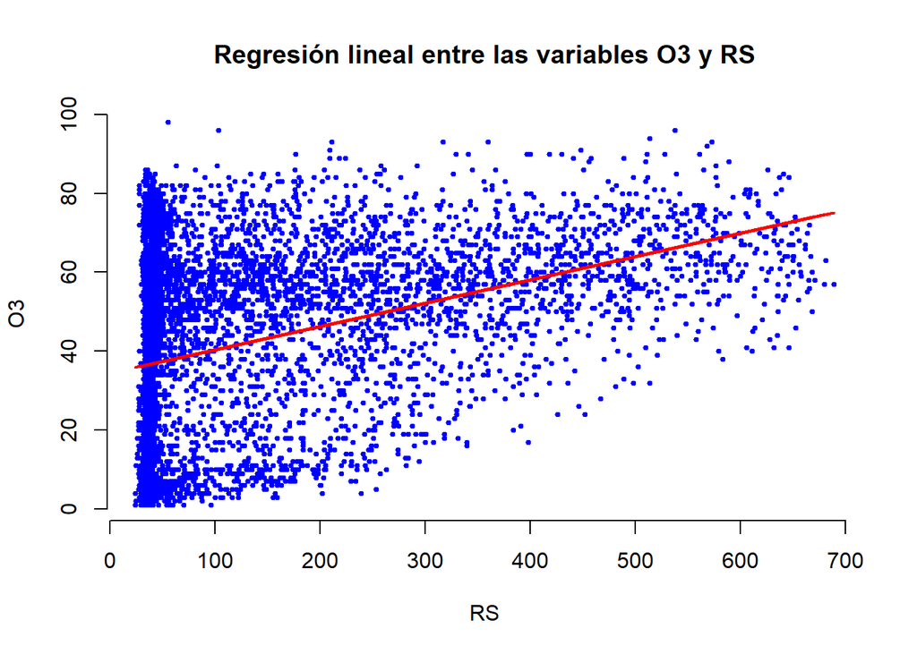

```r
ypred <- rl$fitted.values
plot(d$RS, d$O3,
     main = 'Regresión lineal entre las variables O3 y RS',
     xlab = 'RS',
     ylab = 'O3',
     pch = 19,
     cex = .5,
     col = 'blue',
     frame = FALSE)
lines(d$RS, ypred,
      lwd = 2,
      col = 'red')
```

Obtenemos el coeficiente de determinación $R^{2}$ para evaluar la bondad del ajuste.

```r
summary(rl)$r.squared
```

```
## [1] 0.1381958
```

La proporción de varianza explicada por la recta de regresión obtenida es muy baja, lo que indica un grado de ajuste muy bajo.

### **b)** Regresión lineal entre *O3* y *PM10_cat*

Creamos una nueva variable categórica a partir de la variable numérica *PM10* en función de las siguientes etiquetas:

- Nueva etiqueta *Muy buena*: incluirá el rango de valores *(0, 40]*.
- Nueva etiqueta *Buena*: incluirá el rango de valores *(40, 60]*.
- Nueva etiquta *Mejorable*: incluirá el rango de valores *(60, 120]*.
- Nueva etiqueta *Mala*: incluirá el rango de valores *(120, 160]*.
- Nueva etiqueta *Muy mala*: incluirá el rango de valores *(160, 724]*.

```r
PM10_cat <- numeric()
PM10_cat[d$PM10 <= 40] <- 'Muy buena'
PM10_cat[d$PM10 > 40 & d$PM10 <= 60] <- 'Buena'
PM10_cat[d$PM10 > 60 & d$PM10 <= 120] <- 'Mejorable'
PM10_cat[d$PM10 > 120 & d$PM10 <= 160] <- 'Mala'
PM10_cat[d$PM10 > 160 & d$PM10 <= 724] <- 'Muy mala'
PM10_cat <- factor(PM10_cat, levels = c('Muy buena', 'Buena', 'Mejorable', 'Mala', 'Muy mala'))
levels(PM10_cat)
```

```
## [1] "Muy buena" "Buena"     "Mejorable" "Mala"      "Muy mala"
```

Creamos el modelo de regresión lineal con la nueva variable *PM10_cat* como independiente y *O3* como dependiente.

```r
rl <- lm(O3 ~ PM10_cat, data=d)
summary(rl)
```

```
##
## Call:
## lm(formula = O3 ~ PM10_cat, data = d)
##
## Residuals:
##     Min      1Q  Median      3Q     Max
## -50.586 -10.586   0.414  11.414  65.948
##
## Coefficients:
##                   Estimate Std. Error t value Pr(>|t|)
## (Intercept)        51.5862     0.2445  211.00   <2e-16 ***
## PM10_catBuena     -22.2638     0.7270  -30.62   <2e-16 ***
## PM10_catMejorable -36.6130     0.6654  -55.02   <2e-16 ***
## PM10_catMala      -44.1516     1.1768  -37.52   <2e-16 ***
## PM10_catMuy mala  -44.5346     1.1039  -40.34   <2e-16 ***
## ---
## Signif. codes:  0 '***' 0.001 '**' 0.01 '*' 0.05 '.' 0.1 ' ' 1
##
## Residual standard error: 17.72 on 7247 degrees of freedom
## Multiple R-squared:  0.442,  Adjusted R-squared:  0.4417
## F-statistic:  1435 on 4 and 7247 DF,  p-value: < 2.2e-16
```

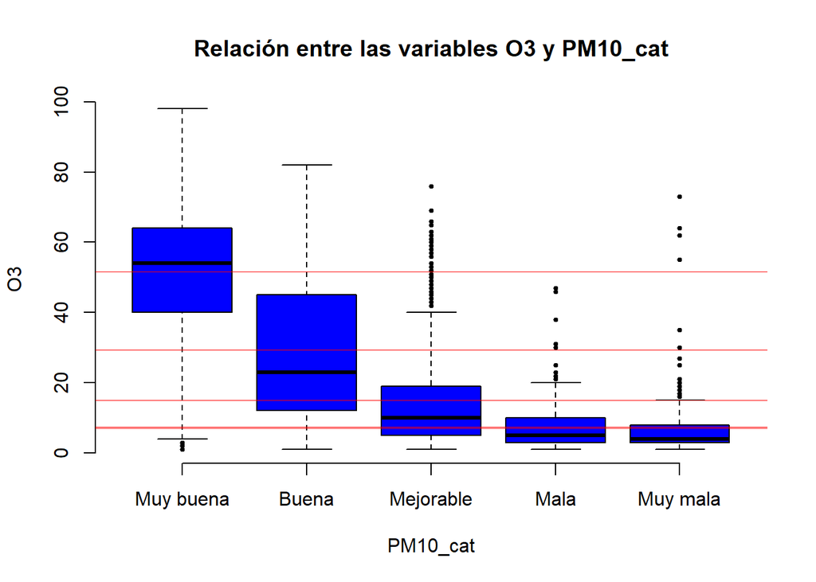

```r
plot(PM10_cat, d$O3,
     main = 'Relación entre las variables O3 y PM10_cat',
     xlab = 'PM10_cat',
     ylab = 'O3',
     pch = 19,
     cex = .5,
     col = 'blue',
     frame = FALSE)
abline(a=rl$coefficients[1], b=0, lwd = .75, col = 'red')
for(i in 2:length(rl$coefficients)){
  abline(a=rl$coefficients[1]+rl$coefficients[i], b=0, lwd = .75, col = 'red')
}
```

El modelo lineal muestra una relación, aunque algo débil, entre la cantidad de *O3* y el índice de calidad del aire (*PM10_cat*), ya que el $R^{2}$ es *0.442*. Por lo tanto, cuanto peor es calidad del aire, menor concentración de ozono; y a mayor calidad del aire, mayor concentración de ozono.

## **1.3. Modelo de regresión lineal múltiple**

Utilizaremos las variables *RS*, *NO2*, *Tmp* y *Dir_Aire* para explicar el atributo *O3*.

### **a)** Añadir la variable explicativa *Dir_Aire*

Añadimos *Dir_Aire* como variable explicativa junto a *RS*.

```r
rl <- lm(O3 ~ RS + Dir_Aire, data=d)
rl
```

```
##
## Call:
## lm(formula = O3 ~ RS + Dir_Aire, data = d)
##
## Coefficients:
## (Intercept)           RS     Dir_Aire
##    50.98284      0.04420     -0.07975
```

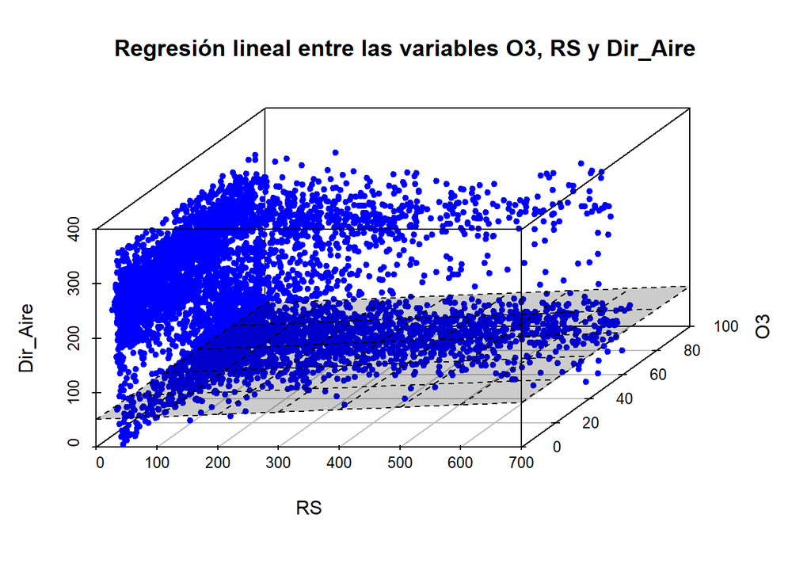

```r
library("scatterplot3d")
space <- scatterplot3d(d$RS, d$O3, d$Dir_Aire,
     main = 'Regresión lineal entre las variables O3, RS y Dir_Aire',
     xlab = 'RS',
     ylab = 'O3',
     zlab = "Dir_Aire",
     pch = 20,
     color = 'blue')
space$plane3d(rl, draw_polygon = TRUE, draw_lines = TRUE)
```

Obtenemos el coeficiente de determinación $R^{2}$ para evaluar la bondad del ajuste.

```r
summary(rl)$r.squared
```

```
## [1] 0.2446094
```

La bondad del modelo original con tan solo la variable *RS* era *0.138*, por lo que **sí** se ha mejorado el modelo añadiendo la variable explicativa *Dir_Aire*.

### **b)** Añadir la variable explicativa *NO2*

Añadimos *NO2* como variable explicativa junto a *RS* y *Dir_Aire*.

```r
rl <- lm(O3 ~ RS + Dir_Aire + NO2, data=d)
rl
```

```
##
## Call:
## lm(formula = O3 ~ RS + Dir_Aire + NO2, data = d)
##
## Coefficients:
## (Intercept)           RS     Dir_Aire          NO2
##    67.89815      0.03395     -0.06315     -1.43679
```

Obtenemos el coeficiente de determinación $R^{2}$ para evaluar la bondad del ajuste.

```r
summary(rl)$r.squared
```

```
## [1] 0.5812012
```

La bondad del modelo original con las variables *RS* y *Dir_Aire* era *0.244*, por lo que **sí** se ha mejorado el modelo añadiendo la variable explicativa *NO2*.

### **c)** Añadir la variable explicativa *Tmp* y estudiar colinealidad entre *Tmp* y *RS*

Añadimos *Tmp* como variable explicativa junto a *RS*, *Dir_Aire* y *NO2* para estudiar la colinealidad.

```r
library(faraway)
rl <- lm(O3 ~ RS + Dir_Aire + NO2 + Tmp, data=d)
cat('Correlación entre RS y Tmp:', cor(d$RS, d$Tmp), '\nR^2 del modelo con RS y Tmp:', summary(rl)$r.squared, '\n')
```

```
## Correlación entre RS y Tmp: 0.4032274
## R^2 del modelo con RS y Tmp: 0.5813616
```

```r
vif(rl)
```

```
##       RS Dir_Aire      NO2      Tmp
## 1.242683 1.116106 1.155859 1.369280
```

Vemos que la correlación entre las variables *RS* y *Tmp* es débil. Además, el estudio del FIV muestra que ninguna variable independiente del modelo está lo suficientemente explicada por el resto de variables combinadas, lo que indica que no existe colinealidad entre las variables. Por lo tanto, se puede incluir *Tmp* al modelo.

```r
rl
```

```
##
## Call:
## lm(formula = O3 ~ RS + Dir_Aire + NO2 + Tmp, data = d)
##
## Coefficients:
## (Intercept)           RS     Dir_Aire          NO2          Tmp
##    66.63203      0.03318     -0.06274     -1.42606      0.07880
```

Obtenemos el coeficiente de determinación $R^{2}$ para evaluar la bondad del ajuste.

```r
summary(rl)$r.squared
```

```
## [1] 0.5813616
```

El $R^{2}$ del modelo con la variable *Tmp* apenas ha mejorado con respecto al modelo anterior. Esto no significa que *Tmp* presente colinealidad con alguna o varias de las variables explicativas del modelo, sino que dicha variable no aporta más información para explicar la variable dependiente *O3*.

## **1.4. Diagnosis del modelo**

Tomamos el modelo del apartado *1.3. b)*.

```r
rl <- lm(O3 ~ RS + Dir_Aire + NO2, data=d)
```

Obtenemos el gráfico *Valores ajustados vs Residuos*.

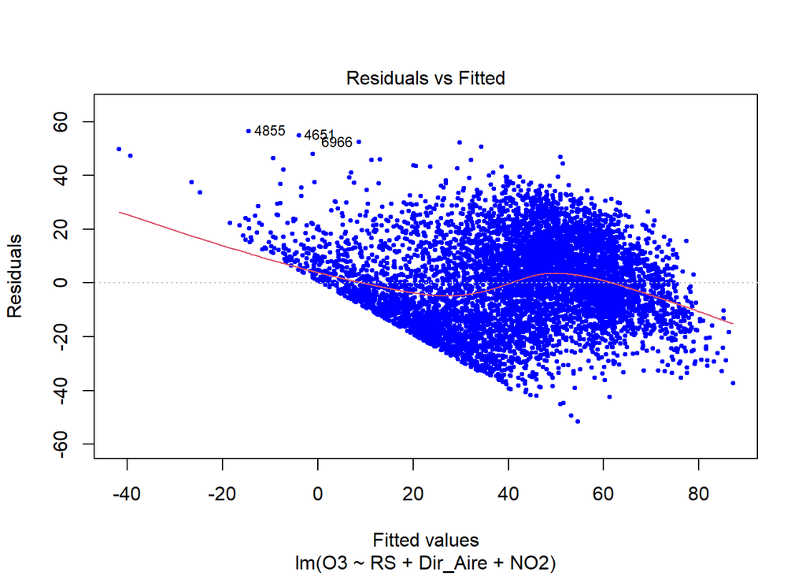

```r
plot(rl,
     which=1,
     pch = 19,
     cex = .5,
     col = 'blue')
```

Se puede apreciar que la distribución de los puntos entorno a la línea del *0* es bastante aleatoria, lo que indica que sí existe cierta linealidad entre las variables. Sin embargo, se aprecia un patrón claro “de corte” en los datos, lo que puede ser indicativo de la presencia de *outliers*.

Ahora obtenemos el gráfico *cuantil-cuantil* (*QQ*).

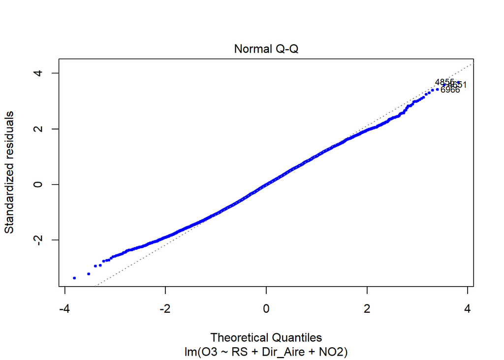

```r
plot(rl,
     which=2,
     pch = 19,
     cex = .5,
     col = 'blue')
```

Visualmente, el gráfico *cuantil-cuantil* se asemeja a una linea recta, por lo que podemos asumir la normalidad.

## **1.5. Predicción del modelo**

Tomamos el modelo del apartado *1.3. c)*.

```r
rl <- lm(O3 ~ RS + Dir_Aire + NO2 + Tmp, data=d)
```

Predecimos el valor de *O3* con los siguientes valores de las variable independientes:

- *RS* = *180*
- *NO2* = *15*
- *Dir_Aire* = *250*
- *Tmp* = *20*

```r
predict(rl,
        data.frame(RS = c(180),
                   NO2 = c(15),
                   Dir_Aire = c(250),
                   Tmp = c(20)
                   )
        )
```

```
##        1
## 37.10378
```

El valor de *O3* predicho por el modelo según los valores de las variables independientes asignados es *37.1*.

# **2. Regresión logística**

Creamos una nueva variable categórica dicotómica *icO3* a partir de la variable numérica *O3* en función de las siguientes etiquetas:

- Nueva etiqueta *Buena*: incluirá el rango de valores *(0, 80]*.
- Nueva etiqueta *Mejorable*: incluirá el rango de valores *(80, 100]*.

```r
icO3 <- numeric()
icO3[d$O3 <= 80] <- 'Buena'
icO3[d$O3 > 80 & d$O3 <= 100] <- 'Mejorable'
icO3 <- factor(icO3, levels = c('Buena', 'Mejorable'))
levels(icO3)
```

```
## [1] "Buena"     "Mejorable"
```

Recodificamos de la siguiente manera:

- *0*: valores etiquetados con *Buena*.
- *1*: valores etiquetados con *Mejorable*.

```r
levels(icO3) <- c(0,1)
levels(icO3)
```

```
## [1] "0" "1"
```

## **2.1. Estudio de relaciones entre variables. Análisis crudo de posibles factores de riesgo**

### **a)** Estudiar la relación de *O3* con *RS*, *Vel* y *HR*

Creamos una nueva variable categórica *RS_cat2* a partir de la variable numérica *RS* en función de las siguientes etiquetas:

- Nueva etiqueta *normal_baja*: incluirá el rango de valores *(0, 100]*.
- Nueva etiqueta *normal_alta*: incluirá el rango de valores *(100, 700]*.

```r
RS_cat2 <- numeric()
RS_cat2[d$RS <= 100] <- 'normal_baja'
RS_cat2[d$RS > 100 & d$RS <= 700] <- 'normal_alta'
RS_cat2 <- factor(RS_cat2, levels = c('normal_baja', 'normal_alta'))
levels(RS_cat2)
```

```
## [1] "normal_baja" "normal_alta"
```

Creamos una nueva variable categórica *Vel_cat2* a partir de la variable numérica *Vel* en función de las siguientes etiquetas:

- Nueva etiqueta *flojo*: incluirá el rango de valores *(0, 3]*.
- Nueva etiqueta *moderado*: incluirá el rango de valores *(3, 10]*.

```r
Vel_cat2 <- numeric()
Vel_cat2[d$Vel <= 3] <- 'flojo'
Vel_cat2[d$Vel > 3 & d$Vel <= 10] <- 'moderado'
Vel_cat2 <- factor(Vel_cat2, levels = c('flojo', 'moderado'))
levels(Vel_cat2)
```

```
## [1] "flojo"    "moderado"
```

Realizamos el test *Chi-cuadrado* de *Pearson* para estudiar la relación entre *O3* y las variables explicativas.

```r
chisq.test(table(icO3, RS_cat2))
```

```
##
##  Pearson's Chi-squared test with Yates' continuity correction
##
## data:  table(icO3, RS_cat2)
## X-squared = 51.188, df = 1, p-value = 8.395e-13
```

Con un *p-valor* de aprox. *0*, se puede rechazar la no independencia de las variables. Por lo tanto, se puede afirmar que existe una asociación entre *icO3* y *RS_cat2*.

```r
chisq.test(table(icO3, Vel_cat2))
```

```
##
##  Pearson's Chi-squared test with Yates' continuity correction
##
## data:  table(icO3, Vel_cat2)
## X-squared = 16.87, df = 1, p-value = 4.002e-05
```

Con un *p-valor* de aprox. *0*, se puede rechazar la no independencia de las variables. Por lo tanto, se puede afirmar que existe una asociación entre *icO3* y *Vel_cat2*.

```r
rl <- glm(icO3 ~ d$HR, family=binomial(link='logit'))
anova(rl, test ="Chisq")
```

|  | Df | Deviance | Resid. Df | Resid. Dev | Pr(>Chi) |
| --- | --- | --- | --- | --- | --- |
| NULL | NA | NA | 7251 | 1567.109 | NA |
| d$HR | 1 | 33.92908 | 7250 | 1533.180 | 5.715782e-09 |

Con un *p-valor* de aprox. *0*, se puede rechazar la no independencia de las variables. Por lo tanto, se puede afirmar que existe una asociación entre *icO3* y *HR*.

### **b)** *Odds-Ratio*

Creamos la función para calcular el *Odds-Ratio*.

```r
or <- function(x, y){
  p <- c()
  r <- c()
  for(i in seq(1, 4, 2)){
    p <- c(p, ((table(x, y)[i+1] / ((table(x, y)[i]) + table(x, y)[i+1]))*100) / ((table(x, y)[i] / ((table(x, y)[i]) + table(x, y)[i+1]))*100))
  }
  return(p[2]/p[1])
}
```

Visualizamos la tabla de contingencia y calculamos el *Odds-Ratio* de *icO3*~*RS_cat2*.

```r
table(icO3, RS_cat2)
```

```
##     RS_cat2
## icO3 normal_baja normal_alta
##    0        4581        2507
##    1          61         103
```

```r
or(icO3, RS_cat2)
```

```
## [1] 3.085413
```

Ahora, visualizamos la tabla de contingencia y calculamos el *Odds-Ratio* de *icO3*~*Vel_cat2*.

```r
table(icO3, Vel_cat2)
```

```
##     Vel_cat2
## icO3 flojo moderado
##    0  4892     2196
##    1    88       76
```

```r
or(icO3, Vel_cat2)
```

```
## [1] 1.923911
```

## **2.2. Modelo de regresión logística**

### **a)** *icO3* y *RS_cat2*

Construimos el modelo de regresión logística.

```r
rl <- glm(icO3 ~ RS_cat2, family=binomial(link='logit'))
summary(rl)
```

```
##
## Call:
## glm(formula = icO3 ~ RS_cat2, family = binomial(link = "logit"))
##
## Deviance Residuals:
##     Min       1Q   Median       3Q      Max
## -0.2838  -0.2838  -0.1626  -0.1626   2.9435
##
## Coefficients:
##                    Estimate Std. Error z value Pr(>|z|)
## (Intercept)         -4.3188     0.1289 -33.509  < 2e-16 ***
## RS_cat2normal_alta   1.1267     0.1635   6.893 5.47e-12 ***
## ---
## Signif. codes:  0 '***' 0.001 '**' 0.01 '*' 0.05 '.' 0.1 ' ' 1
##
## (Dispersion parameter for binomial family taken to be 1)
##
##     Null deviance: 1567.1  on 7251  degrees of freedom
## Residual deviance: 1517.5  on 7250  degrees of freedom
## AIC: 1521.5
##
## Number of Fisher Scoring iterations: 7
```

Como el coeficiente asociado a la radiación solar es positivo, ésta produce un aumento en la concentración de ozono. Para conocer en qué magnitud, calculamos el *Odds-Ratio* haciendo la exponencial de dicho coeficiente.

```r
exp(coefficients(rl))
```

```
##        (Intercept) RS_cat2normal_alta
##         0.01331587         3.08541330
```

```r
exp(confint(rl))
```

```
##                         2.5 %    97.5 %
## (Intercept)        0.01023206 0.0169732
## RS_cat2normal_alta 2.24757491 4.2713165
```

Este intervalo de confianza nos indica que la probabilidad de que la concentración de ozono sea alta con radiación solar alta es entre *2.24* y *4.27* veces mayor que con radiación solar baja.

Por lo tanto, se puede concluir que **la radiación solar alta es un factor de riesgo para la concentración de ozono**.

### **b)** Confusión: *Tmp*

Construimos el modelo de regresión logística añadiendo la variable *Tmp*.

```r
rl <- glm(icO3 ~ RS_cat2 + d$Tmp, family=binomial(link='logit'))
summary(rl)
```

```
##
## Call:
## glm(formula = icO3 ~ RS_cat2 + d$Tmp, family = binomial(link = "logit"))
##
## Deviance Residuals:
##     Min       1Q   Median       3Q      Max
## -0.4483  -0.2438  -0.1852  -0.1430   3.1386
##
## Coefficients:
##                    Estimate Std. Error z value Pr(>|z|)
## (Intercept)        -5.84283    0.36321 -16.086  < 2e-16 ***
## RS_cat2normal_alta  0.78954    0.17635   4.477 7.57e-06 ***
## d$Tmp               0.10630    0.02237   4.753 2.01e-06 ***
## ---
## Signif. codes:  0 '***' 0.001 '**' 0.01 '*' 0.05 '.' 0.1 ' ' 1
##
## (Dispersion parameter for binomial family taken to be 1)
##
##     Null deviance: 1567.1  on 7251  degrees of freedom
## Residual deviance: 1492.8  on 7249  degrees of freedom
## AIC: 1498.8
##
## Number of Fisher Scoring iterations: 7
```

El coeficiente asociado a la variable *RS_cat2* ha pasado de *1.1267* a *0.7895*, lo que supone una reducción del *30%*. Esto podría ser indicativo de que *Tmp* es una variables de confusión.

Analizamos la relación entre *Tmp* y las variables *icO3* y *RS_cat2*.

```r
rl <- glm(icO3 ~ d$Tmp, family=binomial(link='logit'))
summary(rl)
```

```
##
## Call:
## glm(formula = icO3 ~ d$Tmp, family = binomial(link = "logit"))
##
## Deviance Residuals:
##     Min       1Q   Median       3Q      Max
## -0.4497  -0.2486  -0.2004  -0.1535   3.1054
##
## Coefficients:
##             Estimate Std. Error z value Pr(>|z|)
## (Intercept) -6.07874    0.37035 -16.414  < 2e-16 ***
## d$Tmp        0.14539    0.02127   6.834 8.23e-12 ***
## ---
## Signif. codes:  0 '***' 0.001 '**' 0.01 '*' 0.05 '.' 0.1 ' ' 1
##
## (Dispersion parameter for binomial family taken to be 1)
##
##     Null deviance: 1567.1  on 7251  degrees of freedom
## Residual deviance: 1513.5  on 7250  degrees of freedom
## AIC: 1517.5
##
## Number of Fisher Scoring iterations: 7
```

```r
rl <- glm(RS_cat2 ~ d$Tmp, family=binomial(link='logit'))
summary(rl)
```

```
##
## Call:
## glm(formula = RS_cat2 ~ d$Tmp, family = binomial(link = "logit"))
##
## Deviance Residuals:
##     Min       1Q   Median       3Q      Max
## -1.7661  -0.9475  -0.5785   1.0555   2.5754
##
## Coefficients:
##              Estimate Std. Error z value Pr(>|z|)
## (Intercept) -3.783786   0.115516  -32.76   <2e-16 ***
## d$Tmp        0.210176   0.007114   29.55   <2e-16 ***
## ---
## Signif. codes:  0 '***' 0.001 '**' 0.01 '*' 0.05 '.' 0.1 ' ' 1
##
## (Dispersion parameter for binomial family taken to be 1)
##
##     Null deviance: 9476.3  on 7251  degrees of freedom
## Residual deviance: 8374.7  on 7250  degrees of freedom
## AIC: 8378.7
##
## Number of Fisher Scoring iterations: 4
```

Como podemos observar, la variable *Tmp* está relacionada tanto con *icO3* (estadístico *Wald* = *6.8* y *p-valor* = *0*) como con *RS_cat2* (estadístico *Wald* = *29.55* y *p-valor* = *0*), por lo que podemos concluir que *Tmp* es una variable de confusión.

### **c)** Interacción: *HR*

Construimos el modelo de regresión logística añadiendo la variable *HR*.

```r
rl <- glm(icO3 ~ RS_cat2 + d$HR, family=binomial(link='logit'))
summary(rl)
```

```
##
## Call:
## glm(formula = icO3 ~ RS_cat2 + d$HR, family = binomial(link = "logit"))
##
## Deviance Residuals:
##     Min       1Q   Median       3Q      Max
## -0.4676  -0.2565  -0.1665  -0.1486   3.0106
##
## Coefficients:
##                     Estimate Std. Error z value Pr(>|z|)
## (Intercept)        -2.441700   0.511412  -4.774 1.80e-06 ***
## RS_cat2normal_alta  0.907285   0.173962   5.215 1.83e-07 ***
## d$HR               -0.020793   0.005591  -3.719    2e-04 ***
## ---
## Signif. codes:  0 '***' 0.001 '**' 0.01 '*' 0.05 '.' 0.1 ' ' 1
##
## (Dispersion parameter for binomial family taken to be 1)
##
##     Null deviance: 1567.1  on 7251  degrees of freedom
## Residual deviance: 1504.8  on 7249  degrees of freedom
## AIC: 1510.8
##
## Number of Fisher Scoring iterations: 7
```

El coeficiente asociado a la variable *RS_cat2* ha pasado de *1.1267* a *0.907*, lo que supone una reducción del *20%*. Esto no supone una modificación excesiva, por lo que no se puede concluir que *HR* sea o no una variable de confusión.

Analizamos la relación entre *HR* y las variables *icO3* y *RS_cat2*.

```r
rl <- glm(icO3 ~ d$HR, family=binomial(link='logit'))
summary(rl)
```

```
##
## Call:
## glm(formula = icO3 ~ d$HR, family = binomial(link = "logit"))
##
## Deviance Residuals:
##     Min       1Q   Median       3Q      Max
## -0.4843  -0.2245  -0.1903  -0.1712   2.9089
##
## Coefficients:
##              Estimate Std. Error z value Pr(>|z|)
## (Intercept) -1.170155   0.408972  -2.861  0.00422 **
## d$HR        -0.030460   0.004892  -6.226 4.78e-10 ***
## ---
## Signif. codes:  0 '***' 0.001 '**' 0.01 '*' 0.05 '.' 0.1 ' ' 1
##
## (Dispersion parameter for binomial family taken to be 1)
##
##     Null deviance: 1567.1  on 7251  degrees of freedom
## Residual deviance: 1533.2  on 7250  degrees of freedom
## AIC: 1537.2
##
## Number of Fisher Scoring iterations: 6
```

```r
rl <- glm(RS_cat2 ~ d$HR, family=binomial(link='logit'))
summary(rl)
```

```
##
## Call:
## glm(formula = RS_cat2 ~ d$HR, family = binomial(link = "logit"))
##
## Deviance Residuals:
##    Min      1Q  Median      3Q     Max
## -2.476  -0.805  -0.652   1.092   1.818
##
## Coefficients:
##              Estimate Std. Error z value Pr(>|z|)
## (Intercept)  5.416756   0.202977   26.69   <2e-16 ***
## d$HR        -0.068573   0.002303  -29.78   <2e-16 ***
## ---
## Signif. codes:  0 '***' 0.001 '**' 0.01 '*' 0.05 '.' 0.1 ' ' 1
##
## (Dispersion parameter for binomial family taken to be 1)
##
##     Null deviance: 9476.3  on 7251  degrees of freedom
## Residual deviance: 8368.4  on 7250  degrees of freedom
## AIC: 8372.4
##
## Number of Fisher Scoring iterations: 4
```

Podemos observar que la variable *HR* sí está relacionada tanto con *icO3* (estadístico *Wald* = *-6.2* y *p-valor* = *0*) como con *RS_cat2* (estadístico *Wald* = *-29.78* y *p-valor* = *0*), por lo que podemos concluir que *HR* es una variable de confusión.

Para comprobar la interacción, añadimos al modelo la estimación de interacción entre *RS_cat2* y *HR*.

```r
rl <- glm(icO3 ~ RS_cat2 + d$HR + RS_cat2:d$HR, family=binomial(link='logit'))
summary(rl)
```

```
##
## Call:
## glm(formula = icO3 ~ RS_cat2 + d$HR + RS_cat2:d$HR, family = binomial(link = "logit"))
##
## Deviance Residuals:
##     Min       1Q   Median       3Q      Max
## -0.5836  -0.2786  -0.1594  -0.1209   3.1535
##
## Coefficients:
##                          Estimate Std. Error z value Pr(>|z|)
## (Intercept)              0.082972   0.574202   0.144    0.885
## RS_cat2normal_alta      -3.890190   0.885397  -4.394 1.11e-05 ***
## d$HR                    -0.050482   0.006905  -7.311 2.66e-13 ***
## RS_cat2normal_alta:d$HR  0.057986   0.010626   5.457 4.84e-08 ***
## ---
## Signif. codes:  0 '***' 0.001 '**' 0.01 '*' 0.05 '.' 0.1 ' ' 1
##
## (Dispersion parameter for binomial family taken to be 1)
##
##     Null deviance: 1567.1  on 7251  degrees of freedom
## Residual deviance: 1475.4  on 7248  degrees of freedom
## AIC: 1483.4
##
## Number of Fisher Scoring iterations: 7
```

Con un estadístico *Wald* = *5.457* y un *p-valor* = *0* en el estimador de interacción *RS_cat2*:*d$HR*, podemos concluir que **sí existe interacción entre las variables *RS_cat2* y *HR***.

### **d)** *Dir_Aire*

Creamos el modelos con las variables explicativas *RS_cat2* y *Dir_Aire*.

```r
rl <- glm(icO3 ~ RS_cat2 + d$Dir_Aire, family=binomial(link='logit'))
summary(rl)
```

```
##
## Call:
## glm(formula = icO3 ~ RS_cat2 + d$Dir_Aire, family = binomial(link = "logit"))
##
## Deviance Residuals:
##     Min       1Q   Median       3Q      Max
## -0.4809  -0.2562  -0.1291  -0.0948   3.5544
##
## Coefficients:
##                     Estimate Std. Error z value Pr(>|z|)
## (Intercept)        -2.769448   0.178302 -15.532  < 2e-16 ***
## RS_cat2normal_alta  0.680375   0.167722   4.057 4.98e-05 ***
## d$Dir_Aire         -0.010016   0.001106  -9.057  < 2e-16 ***
## ---
## Signif. codes:  0 '***' 0.001 '**' 0.01 '*' 0.05 '.' 0.1 ' ' 1
##
## (Dispersion parameter for binomial family taken to be 1)
##
##     Null deviance: 1567.1  on 7251  degrees of freedom
## Residual deviance: 1404.9  on 7249  degrees of freedom
## AIC: 1410.9
##
## Number of Fisher Scoring iterations: 8
```

```r
rl <- glm(icO3 ~ RS_cat2, family=binomial(link='logit'))
rl2 <- glm(icO3 ~ RS_cat2 + d$Dir_Aire, family=binomial(link='logit'))
anova(rl, rl2, test ="LRT")
```

|  | Resid. Df | Resid. Dev | Df | Deviance | Pr(>Chi) |
| --- | --- | --- | --- | --- | --- |
| 1 | 7250 | 1517.452 | NA | NA | NA |
| 2 | 7249 | 1404.862 | 1 | 112.5899 | 2.653551e-26 |

Con un *p-valor* = *0*, podemos rechazar la hipótesis de que el modelo con la variable explicativa *RS_cat2* es tan bueno como el modelo con las variables explicativas *RS_cat2* y *Dir_Aire*. Por o tanto, **sí esxiste una mejora del modelo al añadir la variable *Dir_Aire***.

## **2.3. Predicción**

Construimos el modelo del apartado anterior y predecimos el valor de la variables dependiente *icO3* a partir de los siguientes valore de las variables explicativas:

- *RS_cat2* = *normal_alta*
- *Dir_Aire* = *40*

```r
rl <- glm(icO3 ~ RS_cat2 + Dir_Aire, family=binomial(link='logit'), data=d)
predict(rl,
        data.frame(RS_cat2 = c('normal_alta'),
                   Dir_Aire = c(40)),
        type = 'response'
        )
```

```
##          1
## 0.07658241
```

La probabilidad de que la concentración de ozono sea superior a *80* (*icO3* = *1*) con una *RS_cat2* = *normal_alta* y una *Dir_Air* = *40* es del *7.67%*.

## **2.4. Bondad del ajuste**

Antes de aplicar el test *Hosmer-Lemeshow*, hay que transformar la variable dependiente *icO3* de *factor* a numérica, ya que esta función no admite variables dependientes de esta clase.

```r
icO3n <- as.numeric(icO3)
rl <- glm(icO3n ~ RS_cat2 + d$Dir_Aire)
library(ResourceSelection)
```

```
## ResourceSelection 0.2-4   2014-05-19
```

```r
hoslem.test(icO3n, fitted(rl))
```

```
##
##  Hosmer and Lemeshow goodness of fit (GOF) test
##
## data:  icO3n, fitted(rl)
## X-squared = -16.206, df = 8, p-value = 1
```

## **2.5. Curva ROC**

Tomamos el modelo del apartado *d)* y graficamos la curva *ROC*.

```r
rl <- glm(icO3 ~ RS_cat2 + d$Dir_Aire, family=binomial(link='logit'))
library(pROC)
```

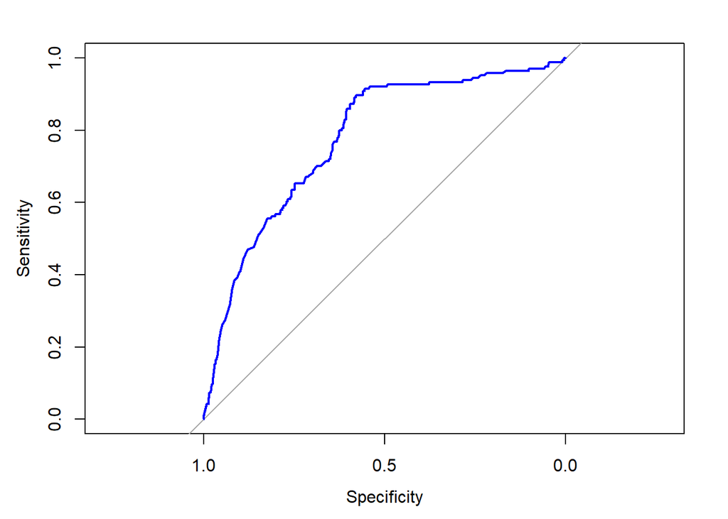

```r
r <- roc(icO3, rl$fitted.values, quiet = TRUE)
plot(r, col = 'blue')
```

```r
auc(r)
```

```
## Area under the curve: 0.7759
```

Con un *AUC* de *0.77*, se puede afirmar que el modelo discrimina bien, pero sin llegar a ser excelente.

# **3. Conclusiones del análisis**

La dificultad de la cosntrucción de modelos predictivos reside en la interpretación y conocimiento de los datos que van a ser tratados. Dependiendo de sus características, será más conveniente (o forzosamente necesario) utilizar un cierto tipo de modelo (por ejemplo, regresión lineal para datos cuantitativos y regresión logística para datos cualitativos), un cireto tipo de test para medir la calidad del ajuste (por ejemplo, *chi-cuadrado* de *Pearson* o test de *Hosmer-Lemeshow*), relaciones entre las variables que pueden llegar a afectar al modelo (confusión, interacción), etc., sabiendo interpretar también los resultados obtenidos en base a ciertos parámentros.

Todo ello es necesario para estudiar y sacar el máximo partido de los datos para que nos lleven a obtener las mejores conclusiones posibles.